# Data Exploration for Flights Data

## Contents:

- Introduction
- Data Wrangling
  - Data Gathering
  - Data Assessment
- Data Analysis
  - Univariate Analysis
    - Data Gather
    - Data Assess
    - Data Clean
    - Data Store
    - Data Analysis
  - Bivariate Analysis
    - Analysis 1
    - Analysis 2
    - Analysis 3
    - Analysis 4
  - Multi-variate Analysis
- Conclusion

## Introduction:

Back to Table of Contents

Data utilized for this project is about Flights and comes from "https://dataverse.harvard.edu/api/access/datafile/:persistentId?persistentId=doi:10.7910/DVN/HG7NV7/EIR0RA", provided by Udacity. I divided data in two different categories; one for univariate analysis and the other for bivariate / multivariate analysis. dataset used for multivariate and bivariate analysis contains more details about individual carrier like all delays, cancellations, total scheduled flights, delay per flight and total duration of delays in minutes. Data has 29 features or we can say columns, and '2389217 number of rows, also contains delays and cancellations information for different carriers.m

## Data Wrangling

### Data Gathering

Back to Table of Contents

```python
# getting all the required libraries
import pandas as pd
import numpy as np
import matplotlib.pyplot as plt
%matplotlib inline
import seaborn as sns
import requests as rq
import os
```

```python
import bz2
from requests import get

def download(web_address):
    req = get(web_address)

    with open('2008.csv.bz2', mode='wb') as file:
        file.write(req.content)

    zipped = bz2.BZ2File('2008.csv.bz2')
    unzip = zipped.read()
    open('2008.csv', 'wb').write(unzip)
    zipped.close()
```

```python
download_08 = download('https://dataverse.harvard.edu/api/access/datafile/:persistentId?persistentId=doi:10.7910/DVN/HG7NV7/EIR0RA')
```

### Data Assessment:

Back to Table of Contents

```python
df_08 = pd.read_csv('2008.csv')
df_08.head()
```

|  | Year | Month | DayofMonth | DayOfWeek | DepTime | CRSDepTime | ArrTime | CRSArrTime | UniqueCarrier | FlightNum | ... | TaxiIn | TaxiOut | Cancelled | CancellationCode | Diverted | CarrierDelay | WeatherDelay | NASDelay | SecurityDelay | LateAircraftDelay |
| --- | --- | --- | --- | --- | --- | --- | --- | --- | --- | --- | --- | --- | --- | --- | --- | --- | --- | --- | --- | --- | --- |
| 0 | 2008 | 1 | 3 | 4 | 1343.0 | 1325 | 1451.0 | 1435 | WN | 588 | ... | 4.0 | 9.0 | 0 | NaN | 0 | 16.0 | 0.0 | 0.0 | 0.0 | 0.0 |
| 1 | 2008 | 1 | 3 | 4 | 1125.0 | 1120 | 1247.0 | 1245 | WN | 1343 | ... | 3.0 | 8.0 | 0 | NaN | 0 | NaN | NaN | NaN | NaN | NaN |
| 2 | 2008 | 1 | 3 | 4 | 2009.0 | 2015 | 2136.0 | 2140 | WN | 3841 | ... | 2.0 | 14.0 | 0 | NaN | 0 | NaN | NaN | NaN | NaN | NaN |
| 3 | 2008 | 1 | 3 | 4 | 903.0 | 855 | 1203.0 | 1205 | WN | 3 | ... | 5.0 | 7.0 | 0 | NaN | 0 | NaN | NaN | NaN | NaN | NaN |
| 4 | 2008 | 1 | 3 | 4 | 1423.0 | 1400 | 1726.0 | 1710 | WN | 25 | ... | 6.0 | 10.0 | 0 | NaN | 0 | 16.0 | 0.0 | 0.0 | 0.0 | 0.0 |

5 rows × 29 columns

```python
# high-level overview of data shape and composition
print(df_08.shape)
print(df_08.dtypes)
```

```
(2389217, 29)
Year                   int64
Month                  int64
DayofMonth             int64
DayOfWeek              int64
DepTime              float64
CRSDepTime             int64
ArrTime              float64
CRSArrTime             int64
UniqueCarrier         object
FlightNum              int64
TailNum               object
ActualElapsedTime    float64
CRSElapsedTime       float64
AirTime              float64
ArrDelay             float64
DepDelay             float64
Origin                object
Dest                  object
Distance               int64
TaxiIn               float64
TaxiOut              float64
Cancelled              int64
CancellationCode      object
Diverted               int64
CarrierDelay         float64
WeatherDelay         float64
NASDelay             float64
SecurityDelay        float64
LateAircraftDelay    float64
dtype: object
```

```python
df_08.describe()
```

|  | Year | Month | DayofMonth | DayOfWeek | DepTime | CRSDepTime | ArrTime | CRSArrTime | FlightNum | ActualElapsedTime | ... | Distance | TaxiIn | TaxiOut | Cancelled | Diverted | CarrierDelay | WeatherDelay | NASDelay | SecurityDelay | LateAircraftDelay |
| --- | --- | --- | --- | --- | --- | --- | --- | --- | --- | --- | --- | --- | --- | --- | --- | --- | --- | --- | --- | --- | --- |
| count | 2389217.0 | 2.389217e+06 | 2.389217e+06 | 2.389217e+06 | 2.324775e+06 | 2.389217e+06 | 2.319121e+06 | 2.389217e+06 | 2.389217e+06 | 2.319121e+06 | ... | 2.389217e+06 | 2.319121e+06 | 2.324775e+06 | 2.389217e+06 | 2.389217e+06 | 584583.000000 | 584583.000000 | 584583.000000 | 584583.000000 | 584583.000000 |
| mean | 2008.0 | 2.505009e+00 | 1.566386e+01 | 3.909625e+00 | 1.340018e+03 | 1.329992e+03 | 1.485835e+03 | 1.496744e+03 | 2.213888e+03 | 1.286189e+02 | ... | 7.261589e+02 | 6.839862e+00 | 1.668584e+01 | 2.697202e-02 | 2.366466e-03 | 15.752957 | 2.938243 | 16.158462 | 0.080459 | 20.976710 |
| std | 0.0 | 1.121493e+00 | 8.750405e+00 | 1.980431e+00 | 4.802717e+02 | 4.657833e+02 | 5.081295e+02 | 4.845238e+02 | 1.951392e+03 | 7.025303e+01 | ... | 5.571763e+02 | 4.846435e+00 | 1.102905e+01 | 1.620017e-01 | 4.858875e-02 | 40.035487 | 19.166662 | 30.534167 | 1.742579 | 38.617154 |
| min | 2008.0 | 1.000000e+00 | 1.000000e+00 | 1.000000e+00 | 1.000000e+00 | 0.000000e+00 | 1.000000e+00 | 1.000000e+00 | 1.000000e+00 | 1.400000e+01 | ... | 1.700000e+01 | 0.000000e+00 | 0.000000e+00 | 0.000000e+00 | 0.000000e+00 | 0.000000 | 0.000000 | 0.000000 | 0.000000 | 0.000000 |
| 25% | 2008.0 | 1.000000e+00 | 8.000000e+00 | 2.000000e+00 | 9.300000e+02 | 9.270000e+02 | 1.110000e+03 | 1.115000e+03 | 6.050000e+02 | 7.800000e+01 | ... | 3.250000e+02 | 4.000000e+00 | 1.000000e+01 | 0.000000e+00 | 0.000000e+00 | 0.000000 | 0.000000 | 0.000000 | 0.000000 | 0.000000 |
| 50% | 2008.0 | 3.000000e+00 | 1.600000e+01 | 4.000000e+00 | 1.330000e+03 | 1.325000e+03 | 1.516000e+03 | 1.520000e+03 | 1.544000e+03 | 1.110000e+02 | ... | 5.830000e+02 | 6.000000e+00 | 1.400000e+01 | 0.000000e+00 | 0.000000e+00 | 0.000000 | 0.000000 | 5.000000 | 0.000000 | 0.000000 |
| 75% | 2008.0 | 4.000000e+00 | 2.300000e+01 | 6.000000e+00 | 1.733000e+03 | 1.720000e+03 | 1.914000e+03 | 1.910000e+03 | 3.631000e+03 | 1.600000e+02 | ... | 9.570000e+02 | 8.000000e+00 | 1.900000e+01 | 0.000000e+00 | 0.000000e+00 | 16.000000 | 0.000000 | 20.000000 | 0.000000 | 27.000000 |
| max | 2008.0 | 4.000000e+00 | 3.100000e+01 | 7.000000e+00 | 2.400000e+03 | 2.359000e+03 | 2.400000e+03 | 2.400000e+03 | 9.741000e+03 | 9.050000e+02 | ... | 4.962000e+03 | 2.130000e+02 | 3.830000e+02 | 1.000000e+00 | 1.000000e+00 | 2436.000000 | 1148.000000 | 1357.000000 | 392.000000 | 1254.000000 |

8 rows × 24 columns

### What is the structure of your dataset?

Dataset includes basically 3 types of data quantitative, qualitative and categorical.  
- quantitative: Distance, Delay etc.  
- qualitative: UniqueCarrier, Origin, Destination etc.  
- categorical: Diverted, CancellationCode, Cancelled etc.  
data includes '2389217 rows and 29 columns. Data is for 2008 USA.

### What is/are the main feature(s) of interest in your dataset?

most interesting features are delays and cancellations based on which I want to figure out performance of airlines

### What features in the dataset do you think will help support your investigation into your feature(s) of interest?

As mentioned earlier, features like CarrierDelay, CancellationCode, Cancelled, Distance, and CarrierDelay  
Based on features undermentioned parameters will be used as criteria for assessment.

- flights cancelled/ hundred flights schedulled
- Carrier delay (min)/ hundred flights operated
- Carrier delay (min)/ hundred miles distance

## Data Analysis:

Back to Table of Contents

### Univariate Analysis

Back to Table of Contents

This section covers individual variables, their distributions.

**Data Gathering:**

```python
#getting full names of carriers
#getting carriers.csv
weburl_car = 'http://stat-computing.org/dataexpo/2009/carriers.csv'
req = rq.get(weburl_car)

with open(os.path.join(weburl_car.split('/')[-1]), mode = 'wb') as file:
  file.write(req.content)
#df_car= df of carriers
df_car = pd.read_csv('carriers.csv')
```

**Data Assessment:**

```python
#UniqueCarriers has abbreviations so, getting its list
lst_car_abr = df_08.UniqueCarrier.value_counts().index

#df_car_name=df of carrier full names
df_car_name = df_car[df_car.Code.isin(lst_car_abr)].reset_index(drop=True)
df_car_name
```

|  | Code | Description |
| --- | --- | --- |
| 0 | 9E | Pinnacle Airlines Inc. |
| 1 | AA | American Airlines Inc. |
| 2 | AQ | Aloha Airlines Inc. |
| 3 | AS | Alaska Airlines Inc. |
| 4 | B6 | JetBlue Airways |
| 5 | CO | Continental Air Lines Inc. |
| 6 | DL | Delta Air Lines Inc. |
| 7 | EV | Atlantic Southeast Airlines |
| 8 | F9 | Frontier Airlines Inc. |
| 9 | FL | AirTran Airways Corporation |
| 10 | HA | Hawaiian Airlines Inc. |
| 11 | MQ | American Eagle Airlines Inc. |
| 12 | NW | Northwest Airlines Inc. |
| 13 | OH | Comair Inc. |
| 14 | OO | Skywest Airlines Inc. |
| 15 | UA | United Air Lines Inc. |
| 16 | US | US Airways Inc. (Merged with America West 9/05... |
| 17 | WN | Southwest Airlines Co. |
| 18 | XE | Expressjet Airlines Inc. |
| 19 | YV | Mesa Airlines Inc. |

**Data Cleaning:**

```python
#stripping off redundant names at the end like airlines inc
df_car_name['name'] = df_car_name.Description.str.split(' A').str[0]
df_car_name['name'] = df_car_name.name.str.split(' I').str[0]
df_car_name.set_index('Code', inplace = True)
df_car_name
```

| Code | Description | name |
| --- | --- | --- |
| 9E | Pinnacle Airlines Inc. | Pinnacle |
| AA | American Airlines Inc. | American |
| AQ | Aloha Airlines Inc. | Aloha |
| AS | Alaska Airlines Inc. | Alaska |
| B6 | JetBlue Airways | JetBlue |
| CO | Continental Air Lines Inc. | Continental |
| DL | Delta Air Lines Inc. | Delta |
| EV | Atlantic Southeast Airlines | Atlantic Southeast |
| F9 | Frontier Airlines Inc. | Frontier |
| FL | AirTran Airways Corporation | AirTran |
| HA | Hawaiian Airlines Inc. | Hawaiian |
| MQ | American Eagle Airlines Inc. | American Eagle |
| NW | Northwest Airlines Inc. | Northwest |
| OH | Comair Inc. | Comair |
| OO | Skywest Airlines Inc. | Skywest |
| UA | United Air Lines Inc. | United |
| US | US Airways Inc. (Merged with America West 9/05... | US |
| WN | Southwest Airlines Co. | Southwest |
| XE | Expressjet Airlines Inc. | Expressjet |
| YV | Mesa Airlines Inc. | Mesa |

```python
#dic_name= dictionary of names with abbreviations
dic_name = dict(df_car_name.name)
dic_name
```

```
{'9E': 'Pinnacle',
 'AA': 'American',
 'AQ': 'Aloha',
 'AS': 'Alaska',
 'B6': 'JetBlue',
 'CO': 'Continental',
 'DL': 'Delta',
 'EV': 'Atlantic Southeast',
 'F9': 'Frontier',
 'FL': 'AirTran',
 'HA': 'Hawaiian',
 'MQ': 'American Eagle',
 'NW': 'Northwest',
 'OH': 'Comair',
 'OO': 'Skywest',
 'UA': 'United',
 'US': 'US',
 'WN': 'Southwest',
 'XE': 'Expressjet',
 'YV': 'Mesa'}
```

```python
#I don't need abbreviations so delete them
df_08.UniqueCarrier.replace(dic_name.keys(), dic_name.values(), inplace = True)
```

**Data Storage:**

```python
df_08.to_csv('df_08_new.csv.bz2')
```

**Analysis and Visualization:**

#### UniqueCarriers:

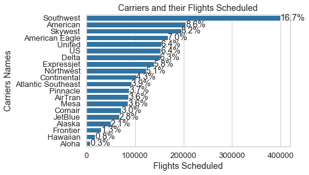

```python
#scheduled flights sorted
car_sort = df_08.UniqueCarrier.value_counts().index

#color
color_pal = sns.color_palette()[0]

#plotting uniqueCarrier
sns.countplot(data = df_08, y = 'UniqueCarrier', color = color_pal, order = car_sort).set_title('Carriers and their Flights Scheduled');
plt.ylabel('Carriers Names')
plt.xlabel('Flights Scheduled')

# percentage of flights scheduled
flight_cnt = df_08.UniqueCarrier.value_counts()
for m in range(flight_cnt.shape[0]):
  cnt = flight_cnt[m]
  pc_str = '{:0.1f}%'.format(100*cnt/df_08.shape[0])
  plt.text(cnt+1, m, pc_str, va = 'center');
```

Southwest Airline has 16.7% of overall flights scheduled, seems to be a big airline. While Aloha has only 0.3% of flights scheduled.

#### Cancelled flights:

Here 1 means cancelled and 0 means not cancelled.

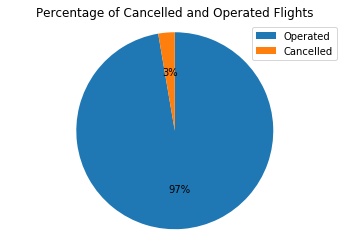

```python
x_cnt = df_08['Cancelled'].value_counts()
pie_labels = 'Operated', 'Cancelled'
plt.pie(x_cnt, startangle = 90, counterclock = False, autopct = '%1.f%%');
plt.axis('equal')
plt.legend(labels = pie_labels)
plt.title('Percentage of Cancelled and Operated Flights')
```

97% of flights scheduled, were operated while 3% were cancelled. It would be intereting to know what caused them to cancel.

#### Cancellation Reasons:

Here A B C D were used as codes for different reasons:

> - A means Cancellation by Carrier
> - B means Cancellation due to Weather
> - C means Cancellation by NAS (National Airspace System)
> - D means Cancellation due to Security

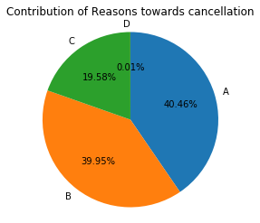

```python
x_cnt = df_08['CancellationCode'].value_counts()
plt.pie(x_cnt, labels = x_cnt.index, startangle = 90,counterclock = False, autopct = '%1.2f%%');
plt.axis('square');
plt.title('Contribution of Reasons towards cancellation');
```

Here security got no representation as it is only 0.01%, let's try another chart

[figure not shown]

```python
#cancelled codes count sorted
xcode_cnt = df_08.CancellationCode.value_counts().index
#plotting cancellation codes
sns.countplot(data = df_08, x = 'CancellationCode', order = xcode_cnt);

plt.xlabel('Reasons of Cancellation')
plt.ylabel('Flights Cancelled')
plt.title('Contribution of Reasons towards Cancellation')
tic = np.arange(4)
plt.xticks(tic, ('Weather', 'Carrier', 'NAS', 'Security'))

# getting percentages
xcodes = df_08.CancellationCode.value_counts()
for k in range(xcodes.shape[0]):
  cnt = xcodes[k]
  pc_str = '{:0.2f}%'.format(100*cnt/df_08[df_08.Cancelled == 1].shape[0])
  plt.text(k-0.25, cnt+400, pc_str, fontsize = 12);
```

We see that security got lowest part in cancellations while weather and carriers turned out to be major reasons. As we don't know more about weather, we can't go deeper. But we do know carriers so we'd find out who cancelled the most.

#### distribution of Distance:

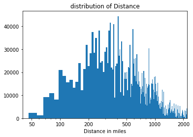

```python
plt.hist(data = df_08, x = 'Distance', bins = 500);
plt.xscale('log')
plt.xticks([50, 1e2, 2e2, 5e2, 1e3, 2e3], [50, '100', '200', '500', '1000', '2000'])
plt.xlabel('Distance in miles')
plt.xlim(40, 2200)
plt.title('distribution of Distance');
```

It looks normal distribution, most fligths travels about 300-400 miles.

#### distribution of CarrierDelay

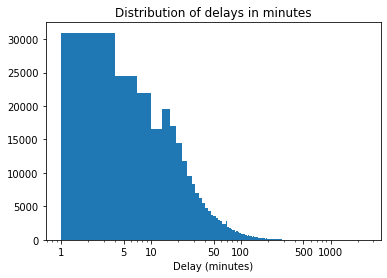

```python
#delay time in minutes due to carrier
plt.hist(data = df_08[df_08.CarrierDelay > 0], x = 'CarrierDelay', bins = 800);
plt.xscale('log')
plt.xticks([1, 5, 10, 50, 100, 500, 1000], [1, 5, 10, 50, 100, 500, 1000])
plt.xlabel('Delay (minutes)')
plt.title('Distribution of delays in minutes');
```

It looks right skewed, most of the delays are appx. 1-10 min

### Discuss the distribution(s) of your variable(s) of interest. Were there any unusual points? Did you need to perform any transformations?

Distance distribution was a normal distribution. We saw some skewness in distribution of delays but it's ok, as it tells us what is delay most of the times. In UniqueCarriers plot we obseved Southwest Airline as a bit different than others but the company is big so it covers more flights than others. Transformations are not required

### Of the features you investigated, were there any unusual distributions? Did you perform any operations on the data to tidy, adjust, or change the form of the data? If so, why did you do this?

Log scale was used in distribution of distance and delays to get a better plot. Data cleaning has been done already.

## Bi-variate Analysis

Back to Table of Contents

For Bi Variate Analysis we'd have to create new columns as parameters, pairs of variables will be assessed in this sections. New columns in the new dataframe would be like:

- column 'carrier_name'=names of the carriers
- column 'num_schedulled'=total flights schedulled
- column 'num_cancelled'=total flights cancelled
- column 'num_delayed'=total flights delayed
- column 'total_delay'=total delay in minutes
- column 'total_distance'=total distance in miles covered

  calculated column would be like:
- column 'pct_cancelled'=flights cancelled per 100 flights schedulled
- column 'pct_delayed'=flights delayed per 100 flights operated
- column 'delay_per_flight'=carrier delay in minutes per flight operated
- column 'delay_per_mile'=carrier delay in minutes per 100 miles distance

```python
#next 5 series are gonna be used in new dataframe
#carrier flights scheduled counut csc
csc1 = df_08.UniqueCarrier.value_counts()
csc1
```

```
Southwest             398966
American              204519
Skywest               195184
American Eagle        167860
United                154036
US                    153539
Delta                 151409
Expressjet            138757
Northwest             122799
Continental           102702
Atlantic Southeast     92383
Pinnacle               88359
AirTran                86856
Mesa                   85686
Comair                 71934
JetBlue                67478
Alaska                 49885
Frontier               30680
Hawaiian               18385
Aloha                   7800
Name: UniqueCarrier, dtype: int64
```

```python
#flights cancelled by the company
csc2 = df_08[df_08.Cancelled == 1].UniqueCarrier.value_counts()
csc2
```

```
American              10784
American Eagle         8960
Skywest                6773
Mesa                   5150
United                 4616
Southwest              4380
Pinnacle               4097
Expressjet             3925
Delta                  3051
Comair                 2618
US                     2390
Atlantic Southeast     2346
Northwest              1407
Continental            1084
AirTran                 903
JetBlue                 902
Alaska                  804
Hawaiian                112
Frontier                 98
Aloha                    42
Name: UniqueCarrier, dtype: int64
```

```python
#flights delayed by the airline
csc3 = df_08[df_08.CarrierDelay > 0].UniqueCarrier.value_counts()
csc3
```

```
Southwest             47405
American              27848
United                18047
American Eagle        17714
Skywest               16215
Northwest             16111
Atlantic Southeast    14648
Expressjet            14270
US                    13952
Delta                 13458
Continental           10539
Mesa                  10068
Comair                 8402
Pinnacle               7796
JetBlue                7297
AirTran                5287
Alaska                 4268
Frontier               4212
Hawaiian                915
Aloha                   233
Name: UniqueCarrier, dtype: int64
```

```python
#delay in minutes
csc4 = df_08.groupby(['UniqueCarrier']).CarrierDelay.sum()
csc4
```

```
UniqueCarrier
AirTran                160494.0
Alaska                 172036.0
Aloha                    8727.0
American              1031402.0
American Eagle         680339.0
Atlantic Southeast     721205.0
Comair                 407430.0
Continental            338712.0
Delta                  472071.0
Expressjet             483047.0
Frontier                91441.0
Hawaiian                38913.0
JetBlue                183732.0
Mesa                   669797.0
Northwest              628606.0
Pinnacle               454496.0
Skywest                786019.0
Southwest              839145.0
US                     390349.0
United                 650950.0
Name: CarrierDelay, dtype: float64
```

```python
#distance covered by carrier
csc5 = df_08[df_08.Cancelled == 0].groupby(['UniqueCarrier']).Distance.sum()
csc5
```

```
UniqueCarrier
AirTran                62157414
Alaska                 45754967
Aloha                   3295411
American              206952498
American Eagle         65188637
Atlantic Southeast     41235140
Comair                 34601723
Continental           115541181
Delta                 139539678
Expressjet             79726250
Frontier               28161259
Hawaiian               11690219
JetBlue                74091841
Mesa                   32002882
Northwest              97478033
Pinnacle               37924726
Skywest                82072947
Southwest             247732017
US                    129621594
United                162814379
Name: Distance, dtype: int64
```

```python
#making a dataframe out of it
df_5 = pd.concat((csc1.rename('num_schedulled'),csc2.rename('num_cancelled'),csc3.rename('num_delayed'),
                  csc4.rename('total_delay'),csc5.rename('total_distance')),axis=1,sort = False).reset_index()
df_5
```

|  | index | num_schedulled | num_cancelled | num_delayed | total_delay | total_distance |
| --- | --- | --- | --- | --- | --- | --- |
| 0 | Southwest | 398966 | 4380 | 47405 | 839145.0 | 247732017 |
| 1 | American | 204519 | 10784 | 27848 | 1031402.0 | 206952498 |
| 2 | Skywest | 195184 | 6773 | 16215 | 786019.0 | 82072947 |
| 3 | American Eagle | 167860 | 8960 | 17714 | 680339.0 | 65188637 |
| 4 | United | 154036 | 4616 | 18047 | 650950.0 | 162814379 |
| 5 | US | 153539 | 2390 | 13952 | 390349.0 | 129621594 |
| 6 | Delta | 151409 | 3051 | 13458 | 472071.0 | 139539678 |
| 7 | Expressjet | 138757 | 3925 | 14270 | 483047.0 | 79726250 |
| 8 | Northwest | 122799 | 1407 | 16111 | 628606.0 | 97478033 |
| 9 | Continental | 102702 | 1084 | 10539 | 338712.0 | 115541181 |
| 10 | Atlantic Southeast | 92383 | 2346 | 14648 | 721205.0 | 41235140 |
| 11 | Pinnacle | 88359 | 4097 | 7796 | 454496.0 | 37924726 |
| 12 | AirTran | 86856 | 903 | 5287 | 160494.0 | 62157414 |
| 13 | Mesa | 85686 | 5150 | 10068 | 669797.0 | 32002882 |
| 14 | Comair | 71934 | 2618 | 8402 | 407430.0 | 34601723 |
| 15 | JetBlue | 67478 | 902 | 7297 | 183732.0 | 74091841 |
| 16 | Alaska | 49885 | 804 | 4268 | 172036.0 | 45754967 |
| 17 | Frontier | 30680 | 98 | 4212 | 91441.0 | 28161259 |
| 18 | Hawaiian | 18385 | 112 | 915 | 38913.0 | 11690219 |
| 19 | Aloha | 7800 | 42 | 233 | 8727.0 | 3295411 |

```python
#calculating new columns as explained above
df_5['pct_cancelled'] = (df_5.num_cancelled / df_5.num_schedulled) * 100
df_5['pct_delayed'] = (df_5.num_delayed / (df_5.num_schedulled - df_5.num_cancelled)) * 100
df_5['delay_per_flight'] = (df_5.total_delay / (df_5.num_schedulled - df_5.num_cancelled))
df_5['delay_per_mile'] = (df_5.total_delay / df_5.total_distance)
```

```python
df_5.rename({'index':'carrier_name'}, axis = 'columns', inplace = True)
df_5.info()
```

```
<class 'pandas.core.frame.DataFrame'>
RangeIndex: 20 entries, 0 to 19
Data columns (total 10 columns):
carrier_name        20 non-null object
num_schedulled      20 non-null int64
num_cancelled       20 non-null int64
num_delayed         20 non-null int64
total_delay         20 non-null float64
total_distance      20 non-null int64
pct_cancelled       20 non-null float64
pct_delayed         20 non-null float64
delay_per_flight    20 non-null float64
delay_per_mile      20 non-null float64
dtypes: float64(5), int64(4), object(1)
memory usage: 1.7+ KB
```

```python
# storing new df to file
df_5.to_csv('car_08_sort.csv')
```

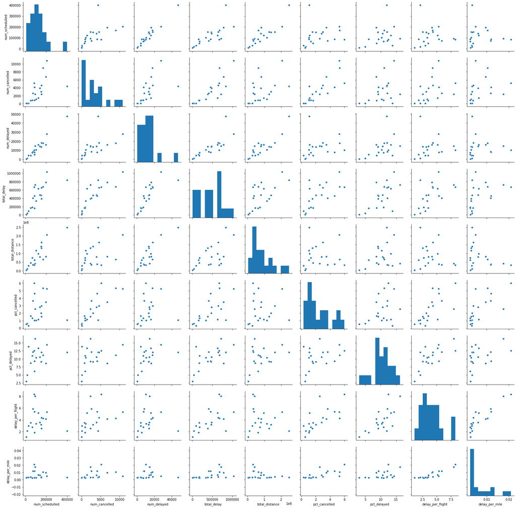

```python
sns.pairplot(df_5);
```

```python
df_5.corr()
```

|  | num_schedulled | num_cancelled | num_delayed | total_delay | total_distance | pct_cancelled | pct_delayed | delay_per_flight | delay_per_mile |
| --- | --- | --- | --- | --- | --- | --- | --- | --- | --- |
| num_schedulled | 1.000000 | 0.584497 | 0.967210 | 0.749489 | 0.864279 | 0.202444 | 0.322989 | -0.018549 | -0.053650 |
| num_cancelled | 0.584497 | 1.000000 | 0.585707 | 0.834966 | 0.468597 | 0.823791 | 0.374155 | 0.398494 | 0.343382 |
| num_delayed | 0.967210 | 0.585707 | 1.000000 | 0.795903 | 0.867905 | 0.218652 | 0.474951 | 0.094457 | 0.005645 |
| total_delay | 0.749489 | 0.834966 | 0.795903 | 1.000000 | 0.632863 | 0.649995 | 0.634515 | 0.572458 | 0.440740 |
| total_distance | 0.864279 | 0.468597 | 0.867905 | 0.632863 | 1.000000 | 0.053332 | 0.337321 | -0.120888 | -0.333821 |
| pct_cancelled | 0.202444 | 0.823791 | 0.218652 | 0.649995 | 0.053332 | 1.000000 | 0.368353 | 0.708288 | 0.706006 |
| pct_delayed | 0.322989 | 0.374155 | 0.474951 | 0.634515 | 0.337321 | 0.368353 | 1.000000 | 0.687291 | 0.435460 |
| delay_per_flight | -0.018549 | 0.398494 | 0.094457 | 0.572458 | -0.120888 | 0.708288 | 0.687291 | 1.000000 | 0.896715 |
| delay_per_mile | -0.053650 | 0.343382 | 0.005645 | 0.440740 | -0.333821 | 0.706006 | 0.435460 | 0.896715 | 1.000000 |

#### flights cancelled by each carrier and comparison with other carriers

Go back to Table of Contents

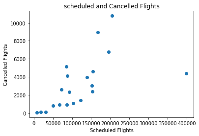

```python
plt.scatter(data = df_5, x = 'num_schedulled', y = 'num_cancelled');
plt.title('scheduled and Cancelled Flights')
plt.xlabel('Scheduled Flights')
plt.ylabel('Cancelled Flights');
```

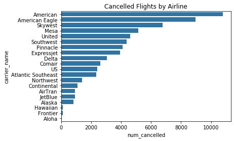

```python
#plotting cancelled flights
color_pal = sns.color_palette()[0]
x_sort = df_5.sort_values('num_cancelled', ascending = False)
x_sort
sns.barplot(x='num_cancelled',y='carrier_name', data=x_sort, color=color_pal).set_title('Cancelled Flights by Airline');
```

We saw earlier that Southwest Airline had most scheduled flights and I wasn't expecting to have more cancellations also but someone else was more eager to be at top and that is American Airlines. But that can be a paradox too, we need to check cancellation per 100 flights.

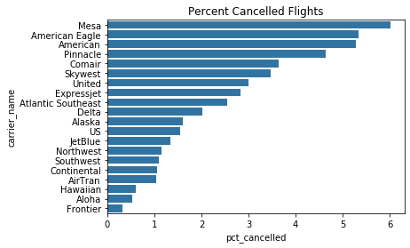

```python
#percentage of cancellations plot
color_pal = sns.color_palette()[0]
pc_x = df_5.sort_values('pct_cancelled', ascending = False)
sns.barplot(x = 'pct_cancelled', y = 'carrier_name', data = pc_x, color = color_pal).set_title('Percent Cancelled Flights');
```

Strangely whole game changed, out of noweher Mesa has proved to be cancelling most flights out of 100. While American Airline went down on third position.

#### flights delayed and their comparison with other Aairlines:

Go back to Table of Contents

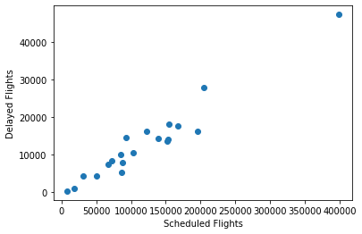

```python
#process is gonna be same like above
plt.scatter(data = df_5, x = 'num_schedulled', y = 'num_delayed');
plt.xlabel('Scheduled Flights')
plt.ylabel('Delayed Flights');
```

We see a strong correlation between the variables, 0.967. It can be represented by a linear line. We can say that this varible num delayed can be ignored as it would have same trend as num scheduled.

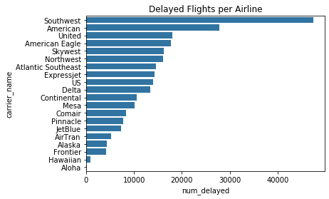

```python
color_pal = sns.color_palette()[0]
delayed = df_5.sort_values('num_delayed', ascending = False)
sns.barplot(x = 'num_delayed', y = 'carrier_name', data = delayed, color = color_pal).set_title('Delayed Flights per Airline');
```

We see that Southwest got most delayed flights but it was expected as it shares most in flights scheduled(16.7%). But we'd look at perrcentages first before making any decision.

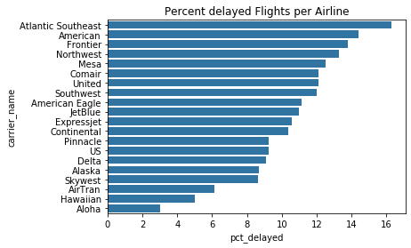

```python
color_pal = sns.color_palette()[0]
pct_delayed = df_5.sort_values('pct_delayed', ascending = False)
sns.barplot(x = 'pct_delayed', y = 'carrier_name', data = pct_delayed, color = color_pal).set_title('Percent delayed Flights per Airline');
```

Again the game changed totally, Atlantic Southeast has more than 16% delays while lowest is Aloha with appx. 3% delays.

#### delay per flight operated

Go back to Table of Contents

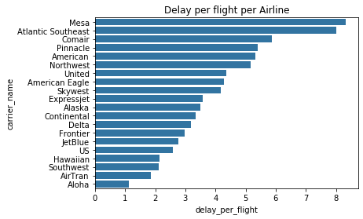

```python
color_pal = sns.color_palette()[0]
delay_pf = df_5.sort_values('delay_per_flight', ascending = False)
sns.barplot(x = 'delay_per_flight', y = 'carrier_name', data = delay_pf, color = color_pal).set_title('Delay per flight per Airline');
```

MESA airlines is highest in terms of delays, it shows 8 min delay per flight, however Aloha exhibits only 1 min delay

#### delay per mile

Go back to Table of Contents

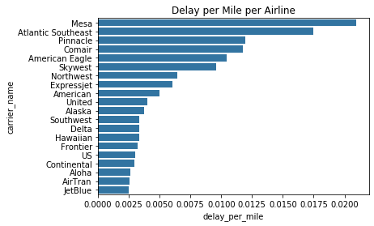

```python
color_pal = sns.color_palette()[0]
delay_pm = df_5.sort_values('delay_per_mile', ascending = False)
sns.barplot(x = 'delay_per_mile', y = 'carrier_name', data = delay_pm, color = color_pal).set_title('Delay per Mile per Airline');
```

though MESA stays on same postion; at top, others changed. But this is not a neutral analysis as what if an airline travels longer distances? then its delay per mile would reduce, so this is not a good parameter

### Talk about some of the relationships you observed in this part of the investigation. How did the feature(s) of interest vary with other features in the dataset?

Main feature chosen as uniquecarrier and it doesn't sho any correlation with others. We've seen above in plots it proves to be a good parameter for decision. As We observed earlier that opposite to our expectations, carriers wwith most scheduled flights were not the ones also having more cancellations, so this parameter is good for decision analysis.

### Did you observe any interesting relationships between the other features (not the main feature(s) of interest)?

Yeah, two variables had a strong correlation those were num_scheduled and num_delayed, as they had a correlation of 0.967.

## Multi-variate Analysis

Back to Table of Contents

Using the parameters described earlier, now we can plot for performance using multi variate analysis. We'd use varibales like 'pct_cancelled', 'pct_delayed' and 'delay_per_flight'.

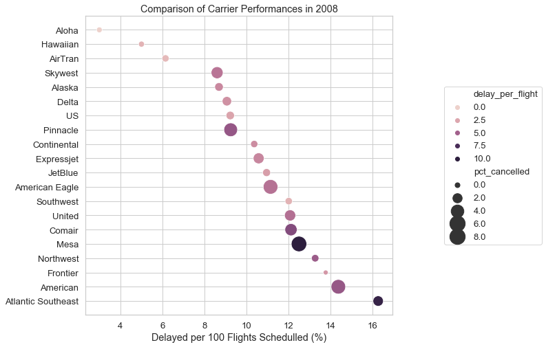

```python
plt.figure(figsize = (8, 8))

cmap = sns.cubehelix_palette(as_cmap=True)
pct_delayed = df_5.sort_values('pct_delayed', ascending = False)

sns.set_style('whitegrid')
sns.set_context("notebook", font_scale=1.2)

# Plot data
sns.scatterplot(data =pct_delayed, x = 'pct_delayed', y = 'carrier_name', hue = 'delay_per_flight',
              size = 'pct_cancelled', palette = cmap, sizes = (50, 500), hue_order = (5, 100)).set_title('Comparison of Carrier Performances in 2008');
plt.legend(loc='center right', bbox_to_anchor=(1.5, 0.5), ncol=1)

plt.xlabel('Delayed per 100 Flights Schedulled (%)')
plt.ylabel('');
```

where: Y axis bottom to top: descending pct_delayed Hue light to dark: delay per flight increasing Size small to large: pct_cancelled increasing

Based on these variables Aloha is best, (Y axis, Hue, Size)=(top, lightest , smaller) Similarly MESA Airlines performed bad, (Y axis, Hue, Size)=( a bit at bottom, darkest, biggest)

| Airline | Y axis position | Hue | Size |
| --- | --- | --- | --- |
| Aloha | Top | Lightest | Smaller |
| MESA | a bit at Bottom | Darkest | Biggest |

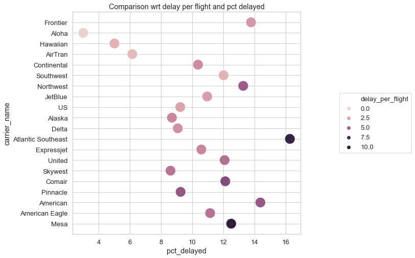

```python
plt.figure(figsize = (8, 8))
cmap = sns.cubehelix_palette(as_cmap=True)
pc_x_2 = df_5.sort_values('pct_cancelled', ascending = False)
sns.set_style('whitegrid')
sns.set_context("notebook", font_scale=1.2)
sns.scatterplot(data = pc_x_2, x = 'pct_delayed', y = 'carrier_name',hue = 'delay_per_flight', palette = cmap,
               hue_order = (50, 1000), s = 400).set_title('Comparison wrt delay per flight and pct delayed');
plt.legend(loc='center right', bbox_to_anchor=(1.5, 0.5), ncol=1);
```

In the plot y axis airlines were arranged in ascending order of percent cancelled and hue was used for delays. However, points are not in a way to conclude somthing, if one if better in one feature, gets bad in other feature.

### Talk about some of the relationships you observed in this part of the investigation. Were there features that strengthened each other in terms of looking at your feature(s) of interest?

We observed in first plot of multivariate analysis how those 4 variables strenghtened each other to conclude a final decision.

### Were there any interesting or surprising interactions between features?

percentage delay increased quickly at start followed by a gradual increase in middle and then increased again at the end quickly.

## Conclusion

Go back to Table of Contents  
In short we can say Aloha is best performer and MESA didn't do so well.